# 03_-*Intro*to_ggplot2_and_Spatial_Analysis

The following steps will create a map to show the percentage of the population in each London Borough who regularly participate in sports activities. To get shapefiles into a format that can be plotted we have to use the **fortify()** function. Spatial objects in R have a number of slots containing the various items of data (polygon geometry, projection, attribute information) associated with a shapefile. The “polygons” slot contains the geometry of the polygons in the form of the XY coordinates used to draw the polygon outline. The generic plot function can work out what to do with these, ggplot2 cannot. We therefore need to extract them as a data frame. This can be done using the fortify function written specifically for this purpose. For fortify to work you need to activate the gpclib library like this.

```r
gpclibPermit()
```

```
## [1] TRUE
```

```r
sport_geom<- fortify(sport, region="ons_label")
```

This step has lost the attribute information associated with the sport object. We can add it back using the merge function (this performs a data join). To find out how this function works look at ?merge.

```r
sport_geom <- merge(sport_geom, sport@data, by.x='id', by.y='ons_label')
```

Have a look at the sport_geom object to see its contents. You should see a large data frame containing the latitude and longitude (they are actually eastings and northings as the data are in British National Grid format) coordinates alongside the attribute information associated with each London Borough. If you type *print(sport_geom)* you will just how many coordinate pairs are required!

```r
head(sport_geom)
```

```
##     id     long      lat order  hole piece  group           name
## 1 00AA 531026.9 181611.1     1 FALSE     1 00AA.1 City of London
## 2 00AA 531554.9 181659.3     2 FALSE     1 00AA.1 City of London
## 3 00AA 532135.6 182198.4     3 FALSE     1 00AA.1 City of London
## 4 00AA 532946.1 181894.8     4 FALSE     1 00AA.1 City of London
## 5 00AA 533410.7 182037.9     5 FALSE     1 00AA.1 City of London
## 6 00AA 533842.7 180793.6     6 FALSE     1 00AA.1 City of London
##   Partic_Per Pop_2001
## 1        9.1     7181
## 2        9.1     7181
## 3        9.1     7181
## 4        9.1     7181
## 5        9.1     7181
## 6        9.1     7181
```

It is now straightforward to produce a map using all the built in tools (such as setting the breaks in the data) that ggplot2 has to offer. coord_equal() is the equivalent of asp=T in regular plots with R:

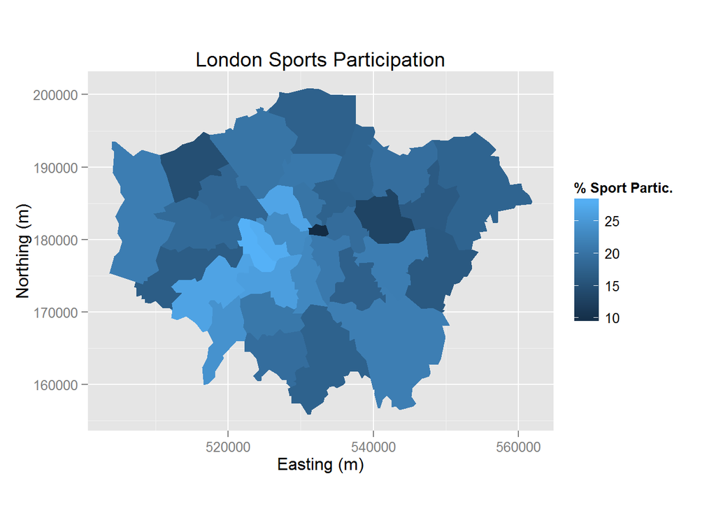

```r
Map <- ggplot(sport_geom, aes(long,lat, group=group, fill=Partic_Per)) + geom_polygon() +
      coord_equal() + labs(x="Easting (m)", y="Northing (m)",fill= "% Sport Partic.") +
      ggtitle ("London Sports Participation")
Map
```

There is a lot going on in the code above. Take a moment to think about what each of the elements of code above has been designed to do. Also note how the **aes()** components can be combined into one set of brackets after ggplot, rather than broken into separate parts as we did above. The different plot functions still know what to do with these. The group=group points ggplot to the group column added by **fortify()** and it identifies the groups of coordinates that pertain to individual polygons (in this case London Boroughs).

The default colours are really nice but we may wish to produce the map in black and white:

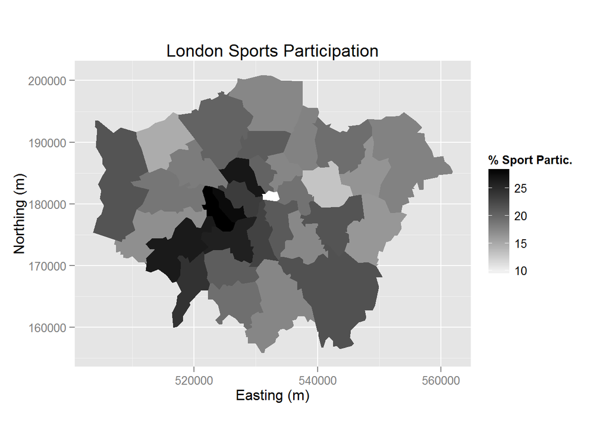

```r
Map + scale_fill_gradient(low="white", high="black")
```

# 3 Using ggplot2 for Descriptive Statistics

For this we will use a new dataset:

```r
input <- read.csv(paste0(data.dir, "/ambulance_assault.csv"))
```

This contains the number of ambulance callouts to assault incidents (downloadable from the London DataStore) between 2009 and 2011.

Take a look at the contents of the file:

```r
head(input)
```

```
##   Bor_Code     WardName WardCode assault_09_11
## 1     00AA   Aldersgate   00AAFA            10
## 2     00AA      Aldgate   00AAFB             0
## 3     00AA    Bassishaw   00AAFC             0
## 4     00AA Billingsgate   00AAFD             0
## 5     00AA  Bishopsgate   00AAFE           188
## 6     00AA Bread Street   00AAFF             0
```

We can now plot a histogram to show the distribution of values.

```r
p_ass<- ggplot(input, aes(x=assault_09_11))
```

Remember the “ggplot(input, aes(x=assault_09_11))” section means create a generic plot object (called p_ass) from the input object using the assault_09_11 column as the data for the x axis. To create the histogram you need to tell R that that is what you want to go with

```
## stat_bin: binwidth defaulted to range/30. Use 'binwidth = x' to adjust this.
```

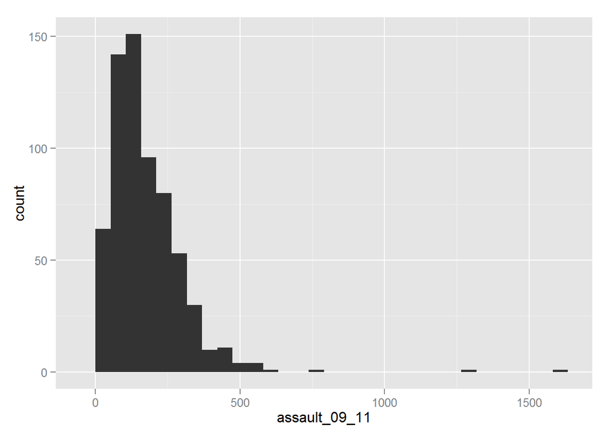

```r
p_ass+geom_histogram()
```

The message

```
stat_bin: binwidth defaulted to range/30. Use 'binwidth = x' to adjust this.
```

relates to the binning, if you want the bins (and therefore the bars) to be thinner (ie representing fewer values) you need to make the bins smaller by adjusting the binwidth. Try:

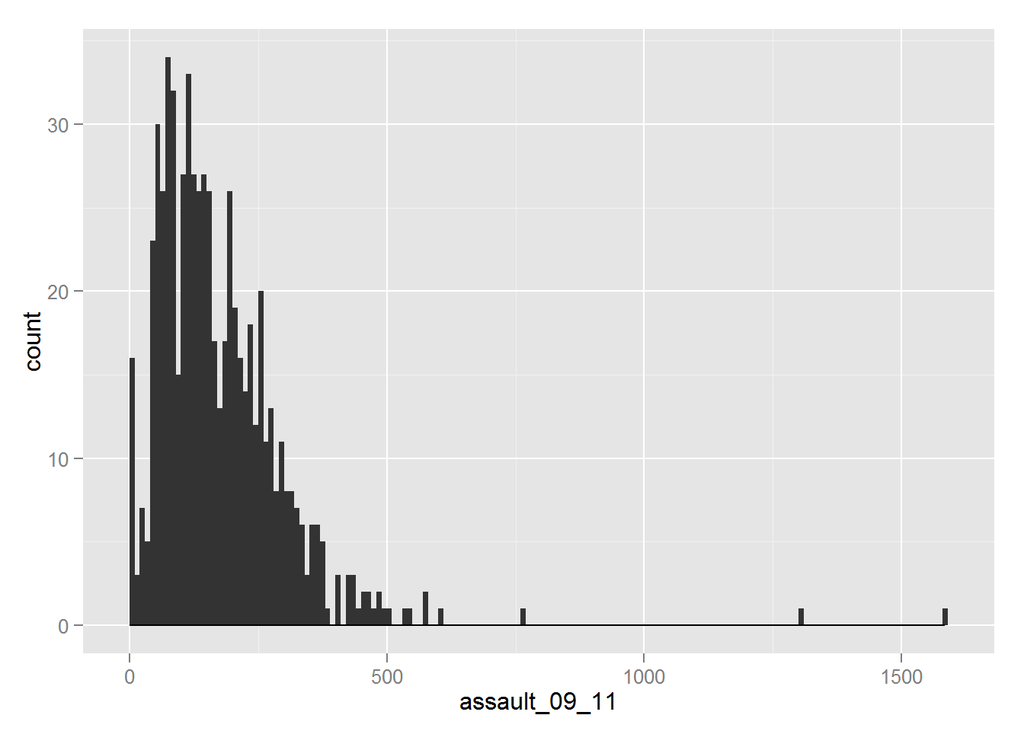

```r
p_ass+geom_histogram(binwidth=10)+geom_density(fill=NA, colour="black")
```

You can also overlay a density distribution over the top of the histogram. For this we need to produce a second plot object that says we wish to use the density distribution as the y variable.

```
## stat_bin: binwidth defaulted to range/30. Use 'binwidth = x' to adjust this.
```

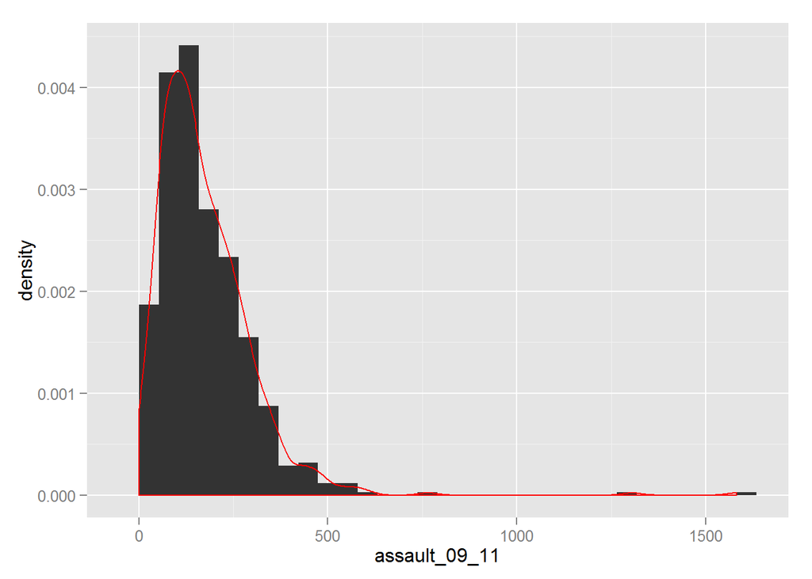

```r
p2_ass <- ggplot(input, aes(x=assault_09_11, y=..density..))
p2_ass + geom_histogram()+geom_density(fill=NA, colour="red")
```

What kind of distribution is this plot showing? You can see that there are a few Wards with very high assault incidences (over 750). To find out which ones these are we can select them (this is similar to what we covered in the previous session).

```r
input[which(input$assault_09_11>750),]
```

```
##     Bor_Code   WardName WardCode assault_09_11
## 153     00AH  Fairfield   00AHGM           765
## 644     00BK St James's   00BKGQ          1582
## 649     00BK   West End   00BKGW          1305
```

It is perhaps unsurprising that St James’s and the West End have the highest counts…This plot has provided a good impression of the overall distribution, but what are the characteristics of each distribution within the Boroughs? Another type of plot that shows the core characteristics of the distribution is a box and whisker plot. These too can be easily produced in R (you can’t do them in Excel!). We can create a third plot object (note that the assault field is now y and not x):

```r
p3_ass<-ggplot(input, aes(x=Bor_Code,y=assault_09_11))
```

and convert it to a boxplot

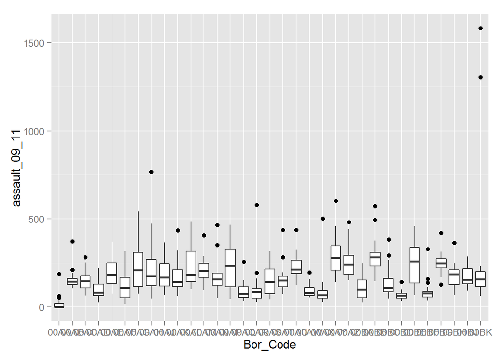

```r
p3_ass+geom_boxplot()
```

I think this would look a little better flipped round

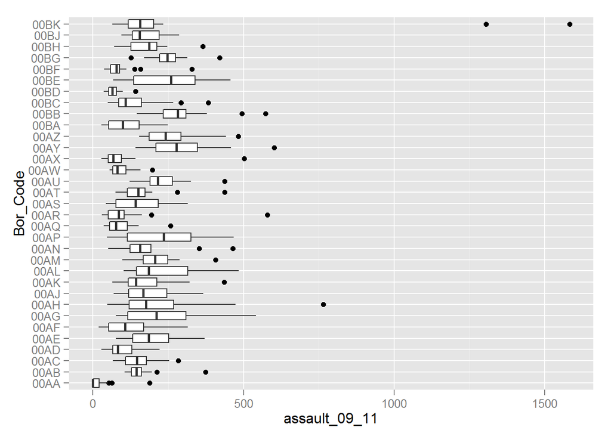

```r
p3_ass+geom_boxplot()+coord_flip()
```

Now each of the borough codes can be easily seen. No surprise that the Borough of Westminster (00BK) has the two largest outliers. In one line of code you have produced an incredibly complex plot rich in information. This demonstrates why R is such a useful program for these kinds of statistics.

If you want an insight into some of the visualisations you can develop with this type of data we can do faceting based on the example of the histogram plot above.

[output not shown]

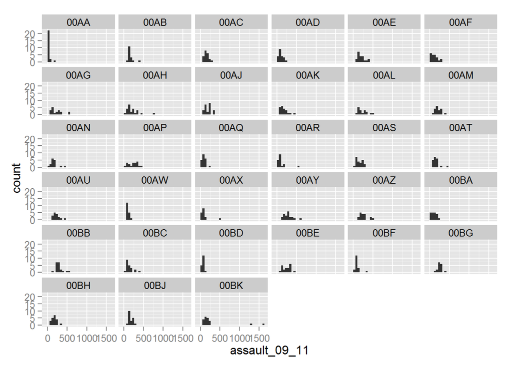

```r
p_ass+geom_histogram()+facet_wrap(~Bor_Code)
```

We need to do a little bit of tweaking to make this plot publishable but I wanted to demonstrate that it is really easy to produce 30+ plots on a single page! Faceting is an extremely powerful way of visualizing multidimensional datasets and is especially good for showing change over time.

# 4 Advanced Task: Faceting for Maps

Load the data- this shows historic population values between 1801 and 2001 for London, again from the London data store.

```r
london.data <- read.csv(paste0(data.dir, "/census-historic-population-borough.csv"))
```

“Melt” the data so that the columns become rows.

```r
london.data.melt <- melt(london.data, id=c("Area.Code", "Area.Name"))
```

Merge the population data with the London borough geometry contained within our sport_geom object.

```r
plot.data <- merge(sport_geom, london.data.melt, by.x="id", by.y="Area.Code")
```

Reorder this data (ordering is important for plots).

```r
plot.data <- plot.data[order(plot.data$order), ]
```

We can now use faceting to produce one map per year (this may take a little while to appear).

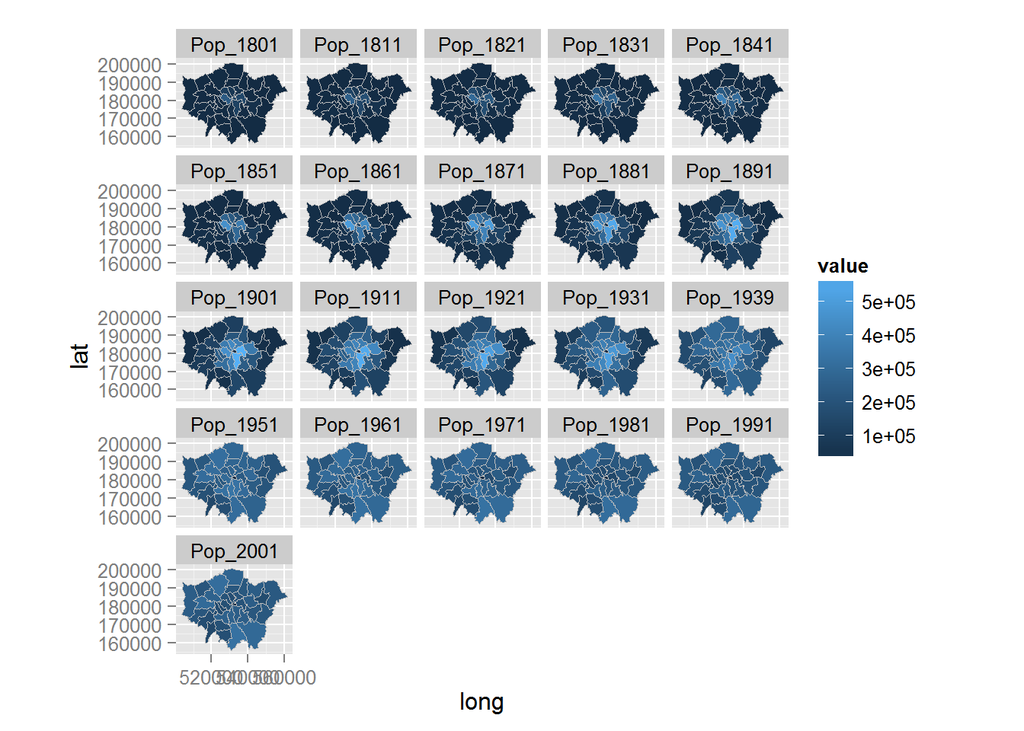

```r
ggplot(data = plot.data, aes(x = long, y = lat, fill = value, group = group))+ geom_polygon() +
      geom_path(colour="grey", lwd=0.1) + coord_equal()+facet_wrap(~variable)
```

Again there is a lot going on here so explore the documentation to make sure you understand it. Try out different colour values as well.

Add a title and replace the axes names with “easting” and ‘northing” and save your map as a pdf.